# STA 9750 Mini-Project #01: Fiscal Characteristics of Major US Public Transit Systems

Author

Yashvi Mittal

Published

September 30, 2025

# Introduction

Public transit systems are public services, engineering projects, and daily economic infrastructure all at once. This report uses the National Transit Database to compare ridership, service mileage, fare revenue, and operating expenses for U.S. transit systems. The central question is not just which agency is largest, but which systems convert resources into useful service most efficiently.

```r
options(repos = c(CRAN = "https://cloud.r-project.org"))
pkgs <- c("tidyverse", "readxl", "lubridate", "DT", "scales", "knitr")
missing_pkgs <- pkgs[!vapply(pkgs, requireNamespace, logical(1), quietly = TRUE)]
if (length(missing_pkgs) > 0) install.packages(missing_pkgs)

library(tidyverse)
library(readxl)
library(lubridate)
library(DT)
library(scales)
library(knitr)

dir.create("data/mp01", recursive = TRUE, showWarnings = FALSE)

download_if_missing <- function(url, dest) {
  if (file.exists(dest) && file.info(dest)$size < 10000) {
    unlink(dest)
  }

  if (!file.exists(dest)) {
    tryCatch(
      download.file(url, destfile = dest, mode = "wb", quiet = FALSE, method = "libcurl"),
      error = function(e) {
        stop(
          "Could not download ", url, ". The NTD site sometimes blocks scripted downloads; ",
          "download it in a browser and save it as ", dest, ". Original error: ",
          conditionMessage(e),
          call. = FALSE
        )
      }
    )
  }
  invisible(dest)
}
```

# Data Acquisition

The assignment provides three NTD sources: 2022 fare revenue, 2022 operating expenses, and the monthly ridership workbook. The code downloads each source only when it is not already present locally.

```r
fare_file <- download_if_missing(
  "https://www.transit.dot.gov/sites/fta.dot.gov/files/2024-04/2022%20Fare%20Revenue.xlsx",
  "data/mp01/2022_fare_revenue.xlsx"
)

expense_file <- download_if_missing(
  "https://data.transportation.gov/api/views/dkxx-zjd6/rows.csv?date=20231102&accessType=DOWNLOAD&bom=true&format=true",
  "data/mp01/2022_expenses.csv"
)

ridership_file <- download_if_missing(
  "https://www.transit.dot.gov/sites/fta.dot.gov/files/2024-09/July%202024%20Complete%20Monthly%20Ridership%20%28with%20adjustments%20and%20estimates%29_240903.xlsx",
  "data/mp01/ridership.xlsx"
)
```

```r
FARES <- read_xlsx(fare_file) |>
  select(
    -`State/Parent NTD ID`, -`Reporter Type`, -`Reporting Module`,
    -TOS, -`Passenger Paid Fares`, -`Organization Paid Fares`
  ) |>
  filter(`Expense Type` == "Funds Earned During Period") |>
  select(-`Expense Type`) |>
  group_by(`NTD ID`, `Agency Name`, Mode) |>
  summarize(`Total Fares` = sum(`Total Fares`, na.rm = TRUE), .groups = "drop")

EXPENSES <- read_csv(expense_file, show_col_types = FALSE) |>
  select(`NTD ID`, Agency, Total, Mode) |>
  mutate(`NTD ID` = as.integer(`NTD ID`)) |>
  rename(Expenses = Total) |>
  group_by(`NTD ID`, Mode) |>
  summarize(Expenses = sum(Expenses, na.rm = TRUE), .groups = "drop")

FINANCIALS <- inner_join(FARES, EXPENSES, join_by(`NTD ID`, Mode))
```

```r
TRIPS <- read_xlsx(ridership_file, sheet = "UPT") |>
  filter(`Mode/Type of Service Status` == "Active") |>
  select(-`Legacy NTD ID`, -`Reporter Type`, -`Mode/Type of Service Status`, -`UACE CD`, -TOS) |>
  pivot_longer(-c(`NTD ID`:`3 Mode`), names_to = "month", values_to = "UPT") |>
  drop_na() |>
  mutate(month = my(month))

MILES <- read_xlsx(ridership_file, sheet = "VRM") |>
  filter(`Mode/Type of Service Status` == "Active") |>
  select(-`Legacy NTD ID`, -`Reporter Type`, -`Mode/Type of Service Status`, -`UACE CD`, -TOS) |>
  pivot_longer(-c(`NTD ID`:`3 Mode`), names_to = "month", values_to = "VRM") |>
  drop_na() |>
  group_by(`NTD ID`, Agency, `UZA Name`, Mode, `3 Mode`, month) |>
  summarize(VRM = sum(VRM, na.rm = TRUE), .groups = "drop") |>
  mutate(month = my(month))

USAGE <- inner_join(TRIPS, MILES) |>
  mutate(`NTD ID` = as.integer(`NTD ID`))
```

# Cleaning

## Task 1: Creating Syntactic Names

```r
USAGE <- USAGE |>
  rename(metro_area = `UZA Name`)
```

## Task 2: Recoding Transit Modes

```r
USAGE |>
  distinct(Mode) |>
  arrange(Mode) |>
  kable(col.names = "Original NTD mode codes")
```

| Original NTD mode codes |
| --- |
| AR |
| CB |
| CC |
| CR |
| DR |
| FB |
| HR |
| IP |
| LR |
| MB |
| MG |
| PB |
| RB |
| SR |
| TB |
| TR |
| VP |
| YR |

```r
recode_ntd_mode <- function(x) {
  case_when(
    x == "AG" ~ "Automated Guideway",
    x == "AR" ~ "Alaska Railroad",
    x == "CB" ~ "Commuter Bus",
    x == "CC" ~ "Cable Car",
    x == "CR" ~ "Commuter Rail",
    x == "DR" ~ "Demand Response",
    x == "DT" ~ "Demand Response Taxi",
    x == "FB" ~ "Ferryboat",
    x == "HR" ~ "Heavy Rail",
    x == "IP" ~ "Inclined Plane",
    x == "LR" ~ "Light Rail",
    x == "MB" ~ "Bus",
    x == "MG" ~ "Monorail/Automated Guideway",
    x == "PB" ~ "Publico",
    x == "RB" ~ "Bus Rapid Transit",
    x == "SR" ~ "Streetcar",
    x == "TB" ~ "Trolleybus",
    x == "VP" ~ "Vanpool",
    x == "YR" ~ "Hybrid Rail",
    TRUE      ~ "Unknown"
  )
}

USAGE <- USAGE |> mutate(Mode = recode_ntd_mode(Mode))

# Apply the same recoding to FINANCIALS so Mode joins line up downstream.
FINANCIALS <- FINANCIALS |> mutate(Mode = recode_ntd_mode(Mode))
```

```r
USAGE |>
  select(-`NTD ID`, -`3 Mode`) |>
  rename(unlinked_passenger_trips = UPT, vehicle_revenue_miles = VRM) |>
  sample_n(min(1000, nrow(USAGE))) |>
  mutate(month = as.character(month)) |>
  datatable(options = list(pageLength = 10, scrollX = TRUE))
```

|  | Agency | metro_area | Mode | month | unlinked_passenger_trips | vehicle_revenue_miles |
| --- | --- | --- | --- | --- | --- | --- |
| 1 | City of Union City | San Francisco--Oakland, CA | Demand Response | 2007-06-01 | 1322 | 6852 |
| 2 | City of Beaumont | Beaumont, TX | Bus | 2019-08-01 | 35636 | 62714 |
| 3 | Santa Clara Valley Transportation Authority | San Jose, CA | Light Rail | 2012-12-01 | 795921 | 258485 |
| 4 | Utah Transit Authority | Salt Lake City, UT | Commuter Bus | 2013-08-01 | 59521 | 81247 |
| 5 | City and County of San Francisco | San Francisco--Oakland, CA | Bus | 2008-04-01 | 7422700 | 1075932 |
| 6 | El Dorado County Transit Authority | Sacramento, CA | Bus | 2015-12-01 | 11704 | 26365 |
| 7 | Milwaukee County | Milwaukee, WI | Bus | 2020-06-01 | 1153105 | 1225480 |
| 8 | Western Reserve Transit Authority | Youngstown, OH | Bus | 2013-08-01 | 123631 | 97697 |
| 9 | City and County of Honolulu | Honolulu, HI | Demand Response | 2005-05-01 | 63495 | 349051 |
| 10 | Chattanooga Area Regional Transportation Authority | Chattanooga, TN--GA | Bus | 2023-02-01 | 85980 | 140626 |

[output cut: 990 more lines]

# Instructor Questions

## Task 3: Core Ridership Questions

```r
agency_most_vrm <- USAGE |>
  group_by(Agency) |>
  summarize(total_vrm = sum(VRM, na.rm = TRUE), .groups = "drop") |>
  slice_max(total_vrm, n = 1, with_ties = FALSE)

mode_most_vrm <- USAGE |>
  group_by(Mode) |>
  summarize(total_vrm = sum(VRM, na.rm = TRUE), .groups = "drop") |>
  slice_max(total_vrm, n = 1, with_ties = FALSE)

nyc_subway_may_2024 <- USAGE |>
  filter(
    str_detect(Agency, regex("Metropolitan Transportation Authority|MTA New York City Transit", ignore_case = TRUE)),
    Mode == "Heavy Rail",
    month == ymd("2024-05-01")
  ) |>
  summarize(trips = sum(UPT, na.rm = TRUE))

nyc_subway_april_change <- USAGE |>
  filter(
    str_detect(Agency, regex("Metropolitan Transportation Authority|MTA New York City Transit", ignore_case = TRUE)),
    Mode == "Heavy Rail",
    month %in% ymd(c("2019-04-01", "2020-04-01"))
  ) |>
  group_by(month) |>
  summarize(trips = sum(UPT, na.rm = TRUE), .groups = "drop") |>
  arrange(month) |>
  mutate(previous_trips = lag(trips), percent_change = (trips - previous_trips) / previous_trips)

mode_longest_avg_trip <- USAGE |>
  filter(month == ymd("2024-05-01"), UPT > 0, VRM > 0) |>
  group_by(Mode) |>
  summarize(
    avg_trip_miles = sum(VRM, na.rm = TRUE) / sum(UPT, na.rm = TRUE),
    .groups = "drop"
  ) |>
  slice_max(avg_trip_miles, n = 1, with_ties = FALSE)

bind_rows(
  tibble(question = "Agency with most total VRM", answer = agency_most_vrm$Agency, value = comma(agency_most_vrm$total_vrm)),
  tibble(question = "Mode with most total VRM", answer = mode_most_vrm$Mode, value = comma(mode_most_vrm$total_vrm)),
  tibble(question = "NYC subway trips in May 2024", answer = "NYC Subway / Heavy Rail", value = comma(nyc_subway_may_2024$trips)),
  tibble(question = "Mode with longest average trip, May 2024", answer = mode_longest_avg_trip$Mode, value = paste0(round(mode_longest_avg_trip$avg_trip_miles, 2), " mi/trip")),
  tibble(question = "NYC subway ridership change, April 2019 to April 2020", answer = "April 2020 relative to April 2019", value = percent(last(na.omit(nyc_subway_april_change$percent_change)), accuracy = 0.1))
) |>
  kable()
```

| question | answer | value |
| --- | --- | --- |
| Agency with most total VRM | MTA New York City Transit | 10,832,855,350 |
| Mode with most total VRM | Bus | 49,444,494,088 |
| NYC subway trips in May 2024 | NYC Subway / Heavy Rail | 182,327,905 |
| Mode with longest average trip, May 2024 | Demand Response | 12.74 mi/trip |
| NYC subway ridership change, April 2019 to April 2020 | April 2020 relative to April 2019 | -90.9% |

The first two answers describe the scale of service production. The NYC subway questions show the pandemic interruption: the April 2020 collapse is a structural shock, not a normal year-over-year fluctuation. I was genuinely surprised by how dominant a single mode and a single agency are — before running this I expected more spread across cities.

To put the NYC pandemic shock in context, the chart below traces NYC subway monthly ridership from 2018 to the most recent month in the data:

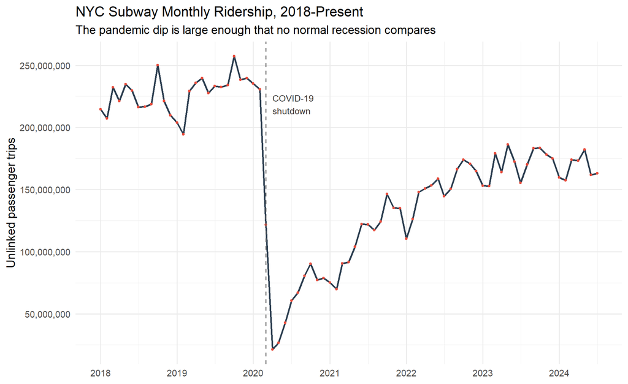

```r
nyc_subway_timeline <- USAGE |>
  filter(
    str_detect(Agency, regex("Metropolitan Transportation Authority|MTA New York City Transit", ignore_case = TRUE)),
    Mode == "Heavy Rail",
    year(month) >= 2018
  ) |>
  group_by(month) |>
  summarize(trips = sum(UPT, na.rm = TRUE), .groups = "drop")

nyc_subway_timeline |>
  ggplot(aes(x = month, y = trips)) +
  geom_line(color = "#2c3e50", linewidth = 0.9) +
  geom_point(color = "#e74c3c", size = 0.8) +
  geom_vline(xintercept = as.numeric(ymd("2020-03-01")), linetype = "dashed", color = "grey40") +
  annotate("text", x = ymd("2020-04-01"), y = max(nyc_subway_timeline$trips) * 0.85,
           label = "COVID-19\nshutdown", color = "grey20", hjust = 0, size = 3.2) +
  scale_y_continuous(labels = comma) +
  scale_x_date(date_breaks = "1 year", date_labels = "%Y") +
  labs(
    title = "NYC Subway Monthly Ridership, 2018-Present",
    subtitle = "The pandemic dip is large enough that no normal recession compares",
    x = NULL, y = "Unlinked passenger trips"
  ) +
  theme_minimal(base_size = 12)
```

## Task 4: Three Additional Transit Facts

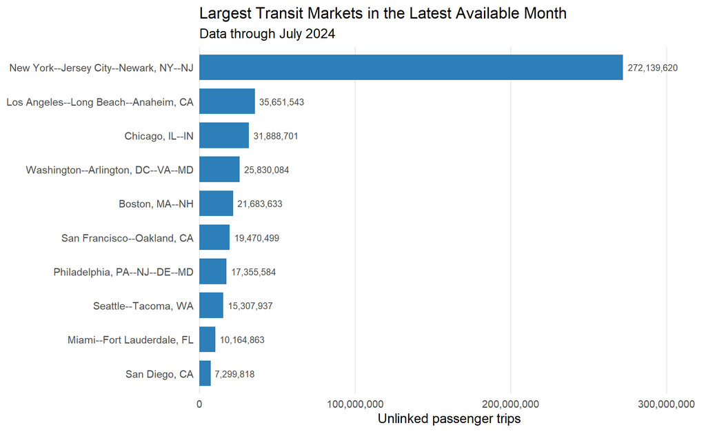

```r
latest_month <- max(USAGE$month, na.rm = TRUE)

top_metros_latest <- USAGE |>
  filter(month == latest_month) |>
  group_by(metro_area) |>
  summarize(trips = sum(UPT, na.rm = TRUE), .groups = "drop") |>
  slice_max(trips, n = 10)

rail_bus_mix <- USAGE |>
  filter(year(month) == 2024) |>
  mutate(category = if_else(Mode %in% c("Heavy Rail", "Commuter Rail", "Light Rail", "Streetcar"), "Rail", "Non-rail")) |>
  group_by(metro_area, category) |>
  summarize(trips = sum(UPT, na.rm = TRUE), .groups = "drop") |>
  group_by(metro_area) |>
  mutate(total_trips = sum(trips), rail_share = if_else(category == "Rail", trips / total_trips, NA_real_)) |>
  ungroup() |>
  filter(total_trips >= 10000000, category == "Rail") |>
  slice_max(rail_share, n = 10)

service_intensity <- USAGE |>
  filter(year(month) == 2024) |>
  group_by(Agency, Mode) |>
  summarize(UPT = sum(UPT, na.rm = TRUE), VRM = sum(VRM, na.rm = TRUE), .groups = "drop") |>
  filter(VRM > 0, UPT >= 1000000) |>
  mutate(trips_per_vrm = UPT / VRM) |>
  slice_max(trips_per_vrm, n = 10)

top_metros_latest |>
  ggplot(aes(x = reorder(metro_area, trips), y = trips)) +
  geom_col(fill = "#2c7fb8", width = 0.75) +
  geom_text(aes(label = comma(trips, accuracy = 1)), hjust = -0.1, size = 3, color = "grey30") +
  coord_flip(clip = "off") +
  scale_y_continuous(labels = comma, expand = expansion(mult = c(0, 0.18))) +
  labs(
    title = "Largest Transit Markets in the Latest Available Month",
    subtitle = paste("Data through", format(latest_month, "%B %Y")),
    x = NULL,
    y = "Unlinked passenger trips"
  ) +
  theme_minimal(base_size = 12) +
  theme(panel.grid.major.y = element_blank(), panel.grid.minor = element_blank())
```

### Fact 1: The largest transit markets dominate national ridership

```r
top_metros_latest |>
  mutate(trips = comma(trips)) |>
  datatable(
    options = list(pageLength = 10, dom = "t", scrollX = TRUE),
    rownames = FALSE,
    colnames = c("Metro Area", "Unlinked Passenger Trips")
  )
```

| Metro Area | Unlinked Passenger Trips |
| --- | --- |
| New York--Jersey City--Newark, NY--NJ | 272,139,620 |
| Los Angeles--Long Beach--Anaheim, CA | 35,651,543 |
| Chicago, IL--IN | 31,888,701 |
| Washington--Arlington, DC--VA--MD | 25,830,084 |
| Boston, MA--NH | 21,683,633 |
| San Francisco--Oakland, CA | 19,470,499 |
| Philadelphia, PA--NJ--DE--MD | 17,355,584 |
| Seattle--Tacoma, WA | 15,307,937 |
| Miami--Fort Lauderdale, FL | 10,164,863 |
| San Diego, CA | 7,299,818 |

### Fact 2: Some large metros are much more rail-oriented

```r
rail_bus_mix |>
  select(metro_area, total_trips, rail_share) |>
  mutate(
    total_trips = comma(total_trips),
    rail_share = percent(rail_share, accuracy = 0.1)
  ) |>
  datatable(
    options = list(pageLength = 10, dom = "t", scrollX = TRUE),
    rownames = FALSE,
    colnames = c("Metro Area", "Total Trips (2024)", "Rail Share")
  )
```

| Metro Area | Total Trips (2024) | Rail Share |
| --- | --- | --- |
| New York--Jersey City--Newark, NY--NJ | 1,921,530,724 | 69.2% |
| Boston, MA--NH | 145,002,825 | 56.8% |
| Washington--Arlington, DC--VA--MD | 194,949,773 | 51.3% |
| San Diego, CA | 49,934,045 | 47.4% |
| Philadelphia, PA--NJ--DE--MD | 126,803,010 | 45.1% |
| Salt Lake City, UT | 22,922,683 | 44.6% |
| Chicago, IL--IN | 209,623,744 | 44.4% |
| Atlanta, GA | 39,402,213 | 44.3% |
| Dallas--Fort Worth--Arlington, TX | 34,888,610 | 39.7% |
| Sacramento, CA | 10,886,459 | 36.7% |

### Fact 3: Trips per vehicle mile identify intensively used service

```r
service_intensity |>
  select(Agency, Mode, UPT, VRM, trips_per_vrm) |>
  mutate(
    UPT = comma(UPT),
    VRM = comma(VRM),
    trips_per_vrm = round(trips_per_vrm, 2)
  ) |>
  datatable(
    options = list(pageLength = 10, dom = "t", scrollX = TRUE),
    rownames = FALSE,
    colnames = c("Agency", "Mode", "Unlinked Passenger Trips", "Vehicle Revenue Miles", "Trips per VRM")
  )
```

| Agency | Mode | Unlinked Passenger Trips | Vehicle Revenue Miles | Trips per VRM |
| --- | --- | --- | --- | --- |
| New York City Department of Transportation | Ferryboat | 9,367,826 | 122,029 | 76.77 |
| Washington State Ferries | Ferryboat | 10,999,952 | 445,115 | 24.71 |
| City and County of San Francisco | Cable Car | 2,028,071 | 114,696 | 17.68 |
| Kansas City, City of Missouri | Streetcar | 1,177,831 | 84,172 | 13.99 |
| City and County of San Francisco | Streetcar | 2,271,777 | 166,295 | 13.66 |
| MTA New York City Transit | Bus Rapid Transit | 21,173,704 | 1,759,872 | 12.03 |
| County of Miami-Dade | Monorail/Automated Guideway | 4,375,851 | 428,162 | 10.22 |
| City of Seattle | Monorail/Automated Guideway | 1,204,093 | 129,210 | 9.32 |
| City and County of San Francisco | Trolleybus | 27,544,805 | 2,963,502 | 9.29 |
| Port Imperial Ferry Corporation | Ferryboat | 2,665,726 | 315,853 | 8.44 |

# Annual 2022 Usage and Finance

## Task 5: Table Summarization

```r
USAGE_2022_ANNUAL <- USAGE |>
  filter(year(month) == 2022) |>
  group_by(`NTD ID`, Agency, metro_area, Mode) |>
  summarize(UPT = sum(UPT, na.rm = TRUE), VRM = sum(VRM, na.rm = TRUE), .groups = "drop")

USAGE_AND_FINANCIALS <- left_join(
  USAGE_2022_ANNUAL,
  FINANCIALS,
  join_by(`NTD ID`, Mode)
) |>
  drop_na() |>
  mutate(
    farebox_recovery = `Total Fares` / Expenses,
    expense_per_upt = Expenses / UPT,
    fare_per_upt = `Total Fares` / UPT,
    expense_per_vrm = Expenses / VRM,
    fare_per_vrm = `Total Fares` / VRM
  )

USAGE_2022_ANNUAL |>
  slice_max(UPT, n = 10) |>
  kable(digits = 2)
```

| NTD ID | Agency | metro_area | Mode | UPT | VRM |
| --- | --- | --- | --- | --- | --- |
| 20008 | MTA New York City Transit | New York–Jersey City–Newark, NY–NJ | Heavy Rail | 1793073801 | 338199451 |
| 20008 | MTA New York City Transit | New York–Jersey City–Newark, NY–NJ | Bus | 458602305 | 82638609 |
| 90154 | Los Angeles County Metropolitan Transportation Authority | Los Angeles–Long Beach–Anaheim, CA | Bus | 193637448 | 124306796 |
| 50066 | Chicago Transit Authority | Chicago, IL–IN | Bus | 140013945 | 44199272 |
| 20080 | New Jersey Transit Corporation | New York–Jersey City–Newark, NY–NJ | Bus | 112739990 | 161834490 |
| 50066 | Chicago Transit Authority | Chicago, IL–IN | Heavy Rail | 103524858 | 66984263 |
| 20188 | MTA Bus Company | New York–Jersey City–Newark, NY–NJ | Bus | 100411771 | 25876153 |
| 30030 | Washington Metropolitan Area Transit Authority | Washington–Arlington, DC–VA–MD | Heavy Rail | 98367576 | 53237986 |
| 30019 | Southeastern Pennsylvania Transportation Authority | Philadelphia, PA–NJ–DE–MD | Bus | 96554641 | 77700310 |
| 30030 | Washington Metropolitan Area Transit Authority | Washington–Arlington, DC–VA–MD | Bus | 89880435 | 37334144 |

## Task 6: Farebox Recovery Among Major Systems

I define a major system as any agency-mode pair with at least 400,000 annual unlinked passenger trips. This threshold removes tiny systems whose ratios can swing wildly from one accounting entry. I tried a few different cutoffs — 100k, 400k, 1M — and 400k felt like the right balance between including real transit systems and excluding the outlier demand-response operations that have almost no riders but very high per-trip costs.

```r
major_systems <- USAGE_AND_FINANCIALS |>
  filter(UPT >= 400000, VRM > 0, Expenses > 0)

summary_questions <- bind_rows(
  major_systems |> slice_max(UPT, n = 1, with_ties = FALSE) |> mutate(metric = "Most UPT in 2022"),
  major_systems |> slice_max(farebox_recovery, n = 1, with_ties = FALSE) |> mutate(metric = "Highest farebox recovery"),
  major_systems |> slice_min(expense_per_upt, n = 1, with_ties = FALSE) |> mutate(metric = "Lowest expenses per UPT"),
  major_systems |> slice_max(fare_per_upt, n = 1, with_ties = FALSE) |> mutate(metric = "Highest total fares per UPT"),
  major_systems |> slice_min(expense_per_vrm, n = 1, with_ties = FALSE) |> mutate(metric = "Lowest expenses per VRM"),
  major_systems |> slice_max(fare_per_vrm, n = 1, with_ties = FALSE) |> mutate(metric = "Highest total fares per VRM")
) |>
  select(metric, Agency, Mode, metro_area, UPT, VRM, `Total Fares`, Expenses, farebox_recovery, expense_per_upt, fare_per_upt, expense_per_vrm, fare_per_vrm)

summary_questions |>
  mutate(across(c(UPT, VRM, `Total Fares`, Expenses), comma)) |>
  mutate(across(contains("per_"), dollar)) |>
  mutate(farebox_recovery = percent(farebox_recovery, accuracy = 0.1)) |>
  datatable(
    options = list(pageLength = 6, dom = "t", scrollX = TRUE),
    rownames = FALSE,
    caption = "Major 2022 transit systems — winner on each efficiency metric"
  )
```

| metric | Agency | Mode | metro_area | UPT | VRM | Total Fares | Expenses | farebox_recovery | expense_per_upt | fare_per_upt | expense_per_vrm | fare_per_vrm |
| --- | --- | --- | --- | --- | --- | --- | --- | --- | --- | --- | --- | --- |
| Most UPT in 2022 | MTA New York City Transit | Heavy Rail | New York--Jersey City--Newark, NY--NJ | 1,793,073,801 | 338,199,451 | 2,326,782,567 | 17,898,259,499 | 13.0% | $9.98 | $1.30 | $52.92 | $6.88 |
| Highest farebox recovery | Port Imperial Ferry Corporation | Ferryboat | New York--Jersey City--Newark, NY--NJ | 3,757,873 | 504,037 | 33,443,241 | 69,954,602 | 47.8% | $18.62 | $8.90 | $138.79 | $66.35 |
| Lowest expenses per UPT | North Carolina State University | Bus | Raleigh, NC | 2,313,091 | 531,555 | 0 | 8,928,664 | 0.0% | $3.86 | $0.00 | $16.80 | $0.00 |
| Highest total fares per UPT | Hampton Jitney, Inc. | Commuter Bus | New York--Jersey City--Newark, NY--NJ | 521,577 | 2,039,368 | 21,539,188 | 55,572,957 | 38.8% | $106.55 | $41.30 | $27.25 | $10.56 |
| Lowest expenses per VRM | San Diego Association of Governments | Vanpool | San Diego, CA | 989,804 | 9,740,828 | 6,021,472 | 16,212,737 | 37.1% | $16.38 | $6.08 | $1.66 | $0.62 |
| Highest total fares per VRM | Jacksonville Transportation Authority | Ferryboat | Jacksonville, FL | 416,129 | 9,084 | 1,432,549 | 10,984,814 | 13.0% | $26.40 | $3.44 | $1,209.25 | $157.70 |

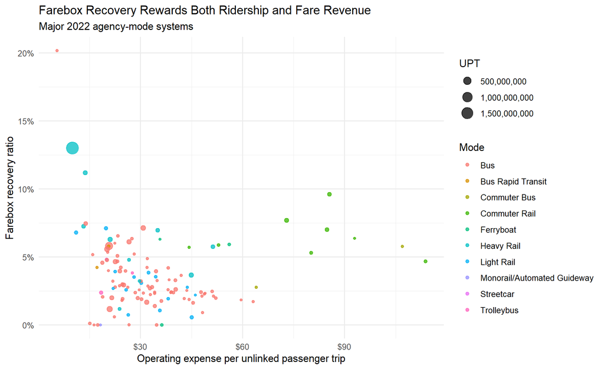

```r
major_systems |>
  filter(UPT >= quantile(UPT, 0.75, na.rm = TRUE)) |>
  ggplot(aes(x = expense_per_upt, y = farebox_recovery, size = UPT, color = Mode)) +
  geom_point(alpha = 0.75) +
  scale_x_continuous(labels = dollar) +
  scale_y_continuous(labels = percent) +
  scale_size_continuous(labels = comma) +
  labs(
    title = "Farebox Recovery Rewards Both Ridership and Fare Revenue",
    subtitle = "Major 2022 agency-mode systems",
    x = "Operating expense per unlinked passenger trip",
    y = "Farebox recovery ratio",
    size = "UPT",
    color = "Mode"
  ) +
  theme_minimal()
```

# Conclusion

The most efficient system depends on how you define efficiency, and I found that no single agency wins on every metric. Farebox recovery rewards systems that collect high fares, while expenses per trip rewards systems that move a lot of people cheaply — and those two goals can pull in opposite directions. I give the most weight to expenses per passenger trip because it directly measures how cheaply a system provides useful rides, regardless of fare policy. That said, the farebox recovery numbers were genuinely surprising to me: some of the systems I expected to be well-run had shockingly low recovery, which made me reconsider what “efficient” actually means in a public-service context. The most convincing candidates for overall efficiency are systems that sit in the top half on multiple metrics rather than dominating just one.